Sankalp Singh Projecty CSCI E104

# Personalizing Text-to-Image Generation using Textual Inversion

Cloned the modified code from personal repository

```python
!git clone https://github.com/sankalpsingh92/textual_inversion.git
!cp -r ./textual_inversion/* .
```

```
Cloning into 'textual_inversion'...
remote: Enumerating objects: 319, done.
remote: Counting objects: 100% (319/319), done.
remote: Compressing objects: 100% (178/178), done.
remote: Total 319 (delta 128), reused 273 (delta 119), pack-reused 0
Receiving objects: 100% (319/319), 46.87 MiB | 24.01 MiB/s, done.
Resolving deltas: 100% (128/128), done.
```

```python
!pip --version
```

```
pip 23.1.2 from /usr/local/lib/python3.10/dist-packages/pip (python 3.10)
```

```python
!pip install -q condacolab
import condacolab
condacolab.install()
```

```
⏬ Downloading https://github.com/conda-forge/miniforge/releases/download/23.11.0-0/Mambaforge-23.11.0-0-Linux-x86_64.sh...
📦 Installing...
📌 Adjusting configuration...
🩹 Patching environment...
⏲ Done in 0:00:09
🔁 Restarting kernel...
```

Set environment variable (the below is needed to parallelize tokenization step)

```python
%env TOKENIZERS_PARALLELISM=true
```

```
env: TOKENIZERS_PARALLELISM=true
```

Install required dependencies for the project

```python
!pip install torch torchvision
!pip install cuda-python
!pip install matplotlib
!pip install numpy==1.22.3
!mkdir -p models/ldm/text2img-large/
!wget -O models/ldm/text2img-large/model.ckpt https://ommer-lab.com/files/latent-diffusion/nitro/txt2img-f8-large/model.ckpt
!pip install albumentations==1.1.0
!pip install opencv-python==4.2.0.34
!pip install pudb==2019.2
!pip install imageio==2.14.1
!pip install imageio-ffmpeg==0.4.7
!pip install omegaconf==2.1.1
!pip install test-tube>=0.7.5
!pip install streamlit>=0.73.1
!pip install setuptools==59.5.0
!pip install pillow==9.0.1
!pip install einops==0.4.1
!pip install torch-fidelity==0.3.0
!pip install transformers==4.18.0
!pip install torchmetrics==0.6.0
!pip install kornia==0.6
!pip install -e git+https://github.com/CompVis/taming-transformers.git@master#egg=taming-transformers
!pip install -e git+https://github.com/openai/CLIP.git@main#egg=clip
!pip install -e .
```

[output not shown]

[output cut: 13 more lines]

[output not shown]

[output not shown]

[output not shown]

[output cut: 26 more lines]

[output not shown]

```python
!pip install pytorch-lightning==1.5.9
!pip install matplotlib
```

[output not shown]

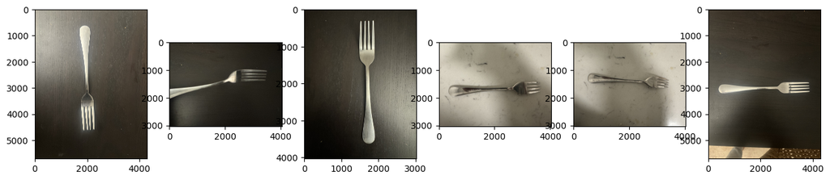

```python
import matplotlib.pyplot as plt
import os
images = dir_list = os.listdir("./images/forks")
fig = plt.figure(figsize=(16, 16))
idx = 1
for imgfile in images:
  img = plt.imread("./images/forks/" + imgfile)
  fig.add_subplot(1, 6, idx)
  idx=idx+1
  plt.imshow(img)
```

Create the embeddings for the above concept, these will be added to the latent space of the base tex-to-image LDM model

```python
!python main.py --base configs/latent-diffusion/txt2img-1p4B-finetune.yaml -t --actual_resume ./models/ldm/text2img-large/model.ckpt -n test1 --gpus 0, --data_root ./images/forks --init_word puppy
```

[output not shown]

[output cut: 4731 more lines]

```
DDIM Sampler:  95% 190/200 [00:26<00:01,  7.18it/s]
DDIM Sampler:  96% 191/200 [00:26<00:01,  7.18it/s]
DDIM Sampler:  96% 192/200 [00:26<00:01,  7.19it/s]
DDIM Sampler:  96% 193/200 [00:26<00:00,  7.19it/s]
DDIM Sampler:  97% 194/200 [00:26<00:00,  7.19it/s]
DDIM Sampler:  98% 195/200 [00:27<00:00,  7.18it/s]
DDIM Sampler:  98% 196/200 [00:27<00:00,  7.18it/s]
DDIM Sampler:  98% 197/200 [00:27<00:00,  7.17it/s]
DDIM Sampler:  99% 198/200 [00:27<00:00,  7.16it/s]
DDIM Sampler: 100% 199/200 [00:27<00:00,  7.13it/s]
DDIM Sampler: 100% 200/200 [00:27<00:00,  7.18it/s]
Epoch 40:  66% 100/152 [01:45<00:55,  1.06s/it, loss=0.119, v_num=0, train/loss_simple_step=0.207, train/loss_vlb_step=0.00129, train/loss_step=0.207, global_step=6099.0, train/loss_simple_epoch=0.122, train/loss_vlb_epoch=0.00197, train/loss_epoch=0.122]   Average Epoch time: 105.87 seconds
Average Peak memory 8668.73MiB
Epoch 40:  79% 120/152 [01:45<00:28,  1.13it/s, loss=0.119, v_num=0, train/loss_simple_step=0.207, train/loss_vlb_step=0.00129, train/loss_step=0.207, global_step=6099.0, train/loss_simple_epoch=0.130, train/loss_vlb_epoch=0.00185, train/loss_epoch=0.130]
Saving latest checkpoint...
```

next give a prompt in this case **a photo of * in a cup** to generate the image with injected *concept*

```python
!python scripts/txt2img.py --ddim_eta 0.0 --n_samples 8 --n_iter 2 --scale 10.0 --ddim_steps 50 --embedding_path /content/logs/$(ls /content/logs -AU | grep forks |  head -1)/checkpoints/embeddings_gs-999.pt --ckpt_path ./models/ldm/text2img-large/model.ckpt --prompt "a photo of * in a cup"
```

[output not shown]

[output cut: 63 more lines]

```
DDIM Sampler:  80% 40/50 [00:09<00:02,  4.35it/s]
DDIM Sampler:  82% 41/50 [00:09<00:02,  4.34it/s]
DDIM Sampler:  84% 42/50 [00:09<00:01,  4.35it/s]
DDIM Sampler:  86% 43/50 [00:09<00:01,  4.35it/s]
DDIM Sampler:  88% 44/50 [00:10<00:01,  4.35it/s]
DDIM Sampler:  90% 45/50 [00:10<00:01,  4.35it/s]
DDIM Sampler:  92% 46/50 [00:10<00:00,  4.35it/s]
DDIM Sampler:  94% 47/50 [00:10<00:00,  4.35it/s]
DDIM Sampler:  96% 48/50 [00:11<00:00,  4.35it/s]
DDIM Sampler:  98% 49/50 [00:11<00:00,  4.34it/s]
DDIM Sampler: 100% 50/50 [00:11<00:00,  4.35it/s]
Sampling: 100% 2/2 [00:23<00:00, 11.98s/it]
Your samples are ready and waiting four you here:
outputs/txt2img-samples
Enjoy.
```

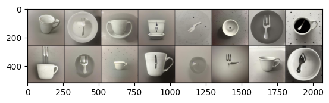

```python
import matplotlib.pyplot as plt
img = plt.imread("./outputs/txt2img-samples/a-photo-of-*-in-a-cup.jpg")
plt.imshow(img)
```

Now I will try inserting a personalized style into the latent space instead of an object, I have used images of plants as the concept

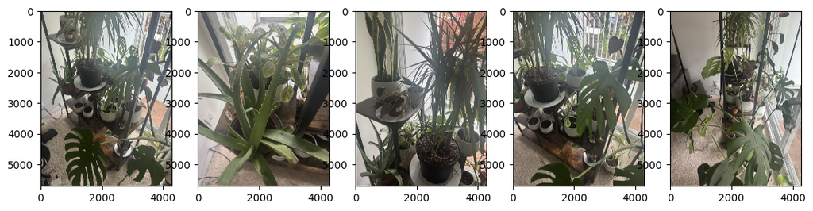

```python
import matplotlib.pyplot as plt
import os
images = dir_list = os.listdir("./images/plants")
fig = plt.figure(figsize=(16, 16))
idx = 1
for imgfile in images:
  img = plt.imread("./images/plants/" + imgfile)
  fig.add_subplot(1, 6, idx)
  idx=idx+1
  plt.imshow(img)
```

Againg Create the embeddings for the above concept, these will be added to the latent space of the base tex-to-image LDM model

```python
!python main.py --base configs/latent-diffusion/txt2img-1p4B-finetune_style.yaml -t --actual_resume ./models/ldm/text2img-large/model.ckpt -n test1 --gpus 0, --data_root ./images/plants --init_word puppy
```

[output not shown]

[output cut: 4945 more lines]

```
DDIM Sampler:  95% 190/200 [00:26<00:01,  7.20it/s]
DDIM Sampler:  96% 191/200 [00:26<00:01,  7.19it/s]
DDIM Sampler:  96% 192/200 [00:26<00:01,  7.19it/s]
DDIM Sampler:  96% 193/200 [00:26<00:00,  7.21it/s]
DDIM Sampler:  97% 194/200 [00:26<00:00,  7.21it/s]
DDIM Sampler:  98% 195/200 [00:27<00:00,  7.19it/s]
DDIM Sampler:  98% 196/200 [00:27<00:00,  7.16it/s]
DDIM Sampler:  98% 197/200 [00:27<00:00,  7.17it/s]
DDIM Sampler:  99% 198/200 [00:27<00:00,  7.18it/s]
DDIM Sampler: 100% 199/200 [00:27<00:00,  7.19it/s]
DDIM Sampler: 100% 200/200 [00:27<00:00,  7.19it/s]
Epoch 48:  79% 100/127 [01:35<00:25,  1.05it/s, loss=0.208, v_num=0, train/loss_simple_step=0.190, train/loss_vlb_step=0.00138, train/loss_step=0.190, global_step=6099.0, train/loss_simple_epoch=0.194, train/loss_vlb_epoch=0.00235, train/loss_epoch=0.194]Average Epoch time: 95.55 seconds
Average Peak memory 8662.49MiB
Epoch 48:  94% 120/127 [01:35<00:05,  1.26it/s, loss=0.208, v_num=0, train/loss_simple_step=0.190, train/loss_vlb_step=0.00138, train/loss_step=0.190, global_step=6099.0, train/loss_simple_epoch=0.202, train/loss_vlb_epoch=0.00248, train/loss_epoch=0.202]
Saving latest checkpoint...
```

next give a prompt in this case **cup in style of *"** to generate the image with injected *concept* this time its a style instead of an object

```python
!python scripts/txt2img.py --ddim_eta 0.0 --n_samples 8 --n_iter 2 --scale 10.0 --ddim_steps 50 --embedding_path /content/logs/$(ls /content/logs -AU | grep plants |  head -1)/checkpoints/embeddings_gs-999.pt --ckpt_path ./models/ldm/text2img-large/model.ckpt --prompt "cup in style of *"
```

[output not shown]

[output cut: 63 more lines]

```
DDIM Sampler:  80% 40/50 [00:09<00:02,  4.35it/s]
DDIM Sampler:  82% 41/50 [00:09<00:02,  4.35it/s]
DDIM Sampler:  84% 42/50 [00:09<00:01,  4.35it/s]
DDIM Sampler:  86% 43/50 [00:09<00:01,  4.35it/s]
DDIM Sampler:  88% 44/50 [00:10<00:01,  4.35it/s]
DDIM Sampler:  90% 45/50 [00:10<00:01,  4.35it/s]
DDIM Sampler:  92% 46/50 [00:10<00:00,  4.35it/s]
DDIM Sampler:  94% 47/50 [00:10<00:00,  4.35it/s]
DDIM Sampler:  96% 48/50 [00:11<00:00,  4.34it/s]
DDIM Sampler:  98% 49/50 [00:11<00:00,  4.35it/s]
DDIM Sampler: 100% 50/50 [00:11<00:00,  4.35it/s]
Sampling: 100% 2/2 [00:23<00:00, 11.98s/it]
Your samples are ready and waiting four you here:
outputs/txt2img-samples
Enjoy.
```

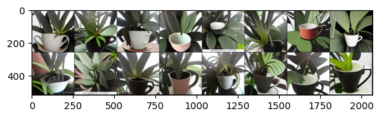

```python
import matplotlib.pyplot as plt
img = plt.imread("./outputs/txt2img-samples/cup-in-style-of-*.jpg")
plt.imshow(img)
```

Plotting the Trainging and validation losses

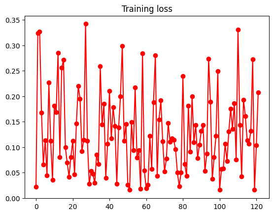

```python
import matplotlib.pyplot as plt
import pandas as pd
!cat /content/logs/$(ls /content/logs -AU | grep forks |  head -1)/testtube/version_0/metrics.csv | awk -F, '{print $3}' | awk NF > metrics_processed_train_loss.csv

data = pd.read_csv('metrics_processed_train_loss.csv')
plt.plot(range(0, len(data['train/loss_simple_step'])), data['train/loss_simple_step'], color='r', label='train loss', marker='o')
plt.title('Training loss')
plt.show()
```

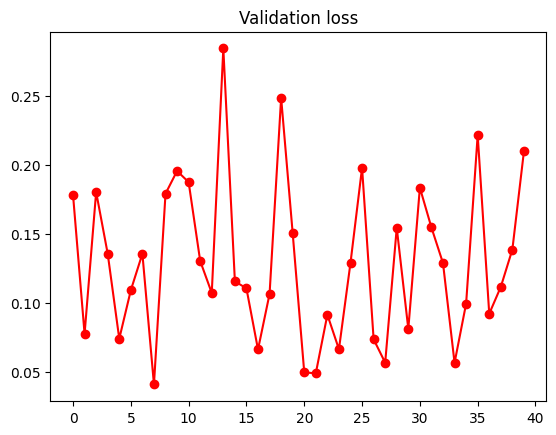

```python
import matplotlib.pyplot as plt
import pandas as pd
!cat /content/logs/$(ls /content/logs -AU | grep forks |  head -1)/testtube/version_0/metrics.csv | awk -F '[,]' '{print $8}' OFS=',' | awk NF > metrics_processed_val_loss.csv

data = pd.read_csv('metrics_processed_val_loss.csv')
data
plt.plot(range(0, len(data['val/loss_simple'])), data['val/loss_simple'], color='r',  marker='o')
plt.title('Validation loss')
plt.show()
```